# TEMA 04 - Construcción de Test

04. DIF y Equiparación de Puntuaciones

Miguel A. Castellanos López

## Funcionamiento Diferencial de los Items (DIF)

[figure not shown]

# Qué es DIF

- *Differential item functioning (DIF)*
- Tradicionalmente estudio del Sesgo
- Empieza a ser relevante en los 60 con los movimientos por los derechos civiles (USA)
- Relacionado con la justicia, equidadad, igualdad de oportunidades, etc.
- Muchos estudios mostraron que los test exageraban o mantenían los prejuicios en sus puntuaciones

### Hay sesgo si dos personas igualmente competentes obtienen puntuaciones distintas por pertenecer a grupos distintos

- Es un tipo de **Error Sistemático**
- Suelen ser de tipo económico o sociocultural
- También hay sesgos no culturales
- La mejor manera de controlarlo es con **expertos**
- También hay métodos empíricos

# $\chi^{2}$ de los aciertos

- Similar al análisis de alternativas
- Un análisis por cada ítem
- Creamos grupos en x (la empírica)
- Representamos la dificultad en tablas de grupos x poblaciones

$$\chi^{2}=\frac{\sum (fo-ft)^{2} }{ft} \Rightarrow \chi^{2}_{1-\alpha, (k-1)(j-1)}$$

```
##         (0,5] (5,10] (19,15] (15,20] (20,25]
## Hombres  0.30   0.30    0.50    0.80    0.85
## Mujeres  0.25   0.33    0.42    0.82    0.83
```

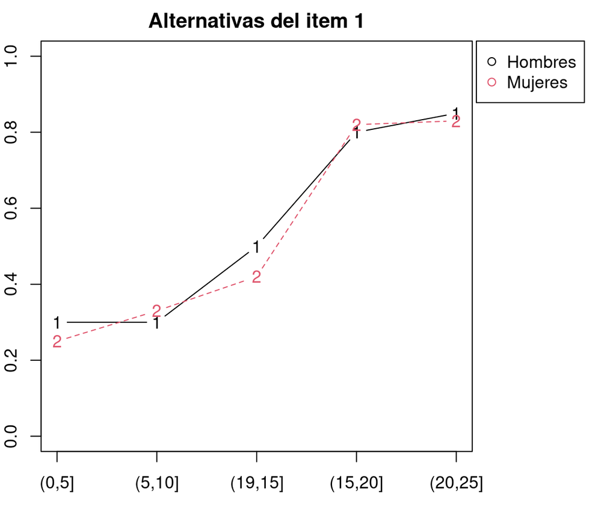

```
##         (0,5] (5,10] (19,15] (15,20] (20,25]
## Hombres  0.30   0.30    0.50    0.80    0.85
## Mujeres  0.25   0.33    0.42    0.58    0.62
```

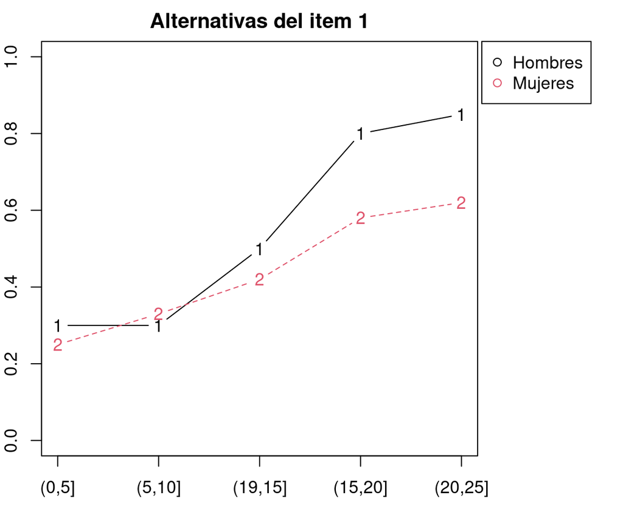

# Mantel-Haenszel

- Un análisis por cada ítem
- Se divide X en subgrupos o niveles (como en $\chi^{2}$)
- Se calcula ($\alpha_{h/m}$) y $\Delta_{h/m}$

$$\alpha_{h/m}=\frac{\sum \frac{AD}{N}}{\sum \frac{BC}{N}}$$
$$\Delta_{h/m}=-2.35ln(\alpha_{h/m})$$

|  |  | (0,5] | (5,10] | (10,15] | (15,20] | (20,25] | SUM |
| --- | --- | --- | --- | --- | --- | --- | --- |
| A | Aciertos (H) | 5 | 20 | 30 | 85 | 10 |  |
| B | Fallos (H) | 5 | 10 | 10 | 20 | 5 |  |
| C | Aciertos (M) | 0 | 5 | 10 | 70 | 15 |  |
| D | Fallos (M) | 10 | 15 | 40 | 30 | 5 |  |
| N | Total | 20 | 45 | 90 | 205 | 35 |  |
|  | numerador | 2.50 | 6.67 | 13.33 | 12.44 | 1.43 | 36.37 |
|  | denominador | 0.00 | 1.11 | 1.11 | 6.83 | 2.14 | 11.19 |

$$\alpha_{h/m}=\frac{36.37}{11.19}=3.24$$
$$\Delta_{h/m}=-2.35ln(3.24)=-2.76$$
Al ser negativo y desviarse de 0 se interpreta como fuerte sesgo contra el grupo de las mujeres

También tienen un contraste de hipótesis

# Método Delta

- Un único análisis para todo el test
- Se calcula el índice de dificultad de cada ítem en cada grupo
- Se tipifican
- Se transforman a la escala delta $\delta = Z_{IDi} 4 + 13$
- Se representan gráficamente las deltas

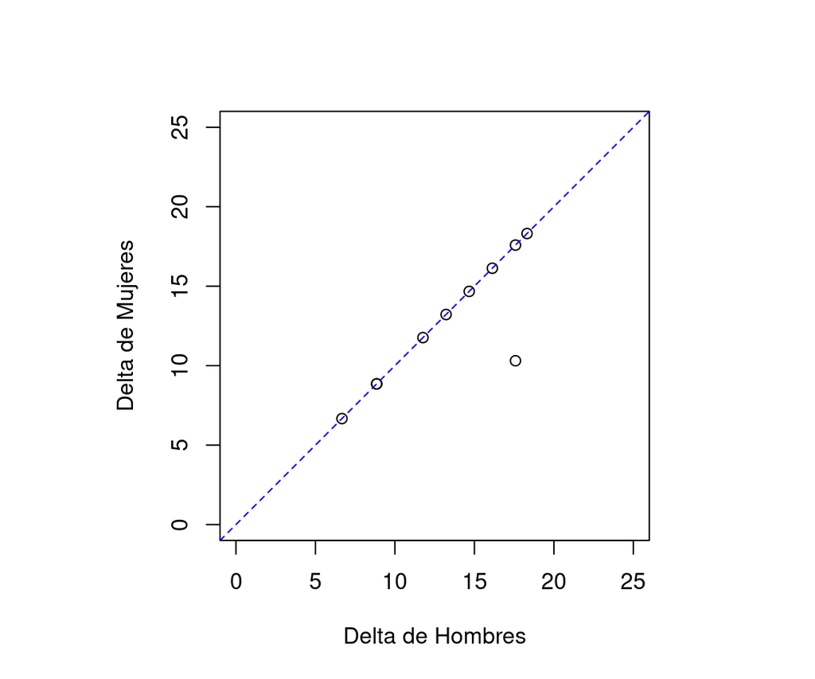

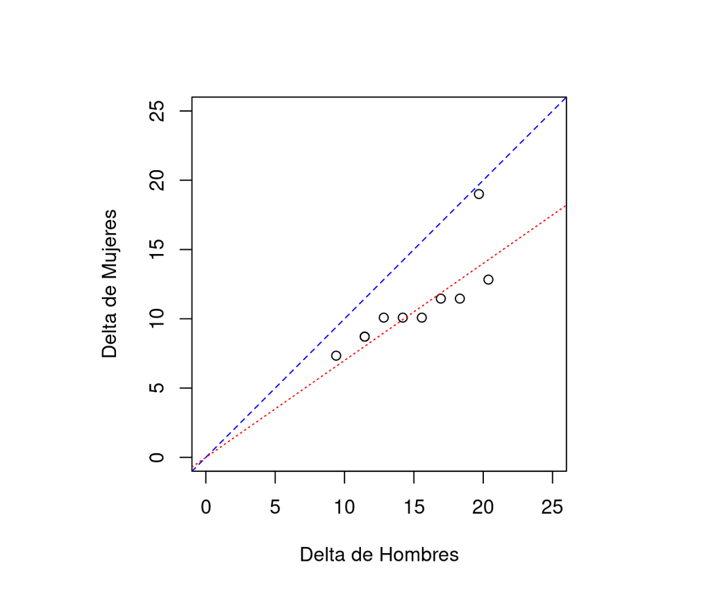

# Odds Ratio

### Odds

- Un Odd son los casos (o proporciones o porcentajes) favorables entre los casos no favorables
- Importante: No es una proporción (se divide entre el total)

$$Odd=\frac{frec+}{frec-}=\frac{Prop+}{Prop-}$$

Ejemplo: De 100 personas con cáncer la supervivencia a 5 años ha sido de 60 personas (40 no lo han superado)

$$Odd=\frac{60}{40}=\frac{0.6}{0.4}=1.5$$

Tienes 1.5 más posibilidades de superar el cáncer que de no superarlo

# Odds Ratio

### Odds Ratio

$$OR = \frac{Odd_{1}}{Odd_{2}}$$

- Un Odd Ratio es la división de dos Odds, cada uno de un grupo o población distinta

Ejemplo: Para las mujeres la proporción de supervivencia a un cáncer es del 80% y para los hombres del 60%

$$OR_{m/h}=\frac{Odd_{mujeres}}{Odd_{hombres}}=\frac{\frac{0.8}{0.2}}{\frac{0.6}{0.4}}=\frac{4}{1.5}=2.6$$

Tienes 2.6 más posibilidades de superar el cáncer siendo mujer que siendo hombre

- Los OR son asimétricos: [0,1,$+\infty$]
- Se pueden transformar para que sean simétricos: ln(OR) [$-\infty$,0,$+\infty$]

$OR = 4/2 = 2 \Rightarrow ln(2)= 0.69$

$OR = 2/4 = 0.5 \Rightarrow ln(0.5)= -0.69$

- Conectan perfectamente con las regresiones logísticas

# Odds Ratio (Agresti, 2002)

- Se pueden calcular para todos los items comparando las dos poblaciones

$$\lambda_{i}=ln \left ( \frac{OR_{R}}{OR_{F}} \right )$$
R y F son el grupo Focal y el de Referencia

- Si el ítem se ajusta al modelo de Rasch entonces:

$$\sigma(\lambda_{i})=\sqrt{\sum frec^{-1}}$$

Y por tanto se pueden construir Intervalos de confianza para el sesgo de cada ítem

$$IC_{i}=\lambda_{i} \pm |Z_{\alpha/2}|\sigma(\lambda_{i})$$
La interpretación es sencilla:

- Cuanto más se aleje de 0 mayor sesgo
- Si el intervalo no incluye el 0 se puede decir que el sesgo es estadísticamente significativo

# Odds Ratio (Agresti, 2002)

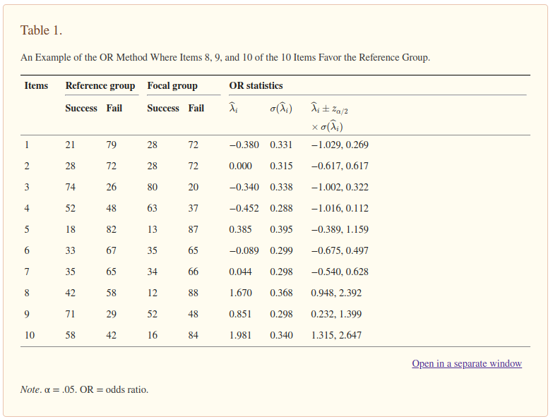

https://www.ncbi.nlm.nih.gov/pmc/articles/PMC6291892/

# Comentarios

- En $\chi^{2}$, Delta y Mantel-Haenszel es necesario suponer que el conjunto de los items ($x$) no está sesgado
- En Odds Ratio no
- En $\chi^{2}$ y Mantel-Haenszel se hace un análisis por ítem
- En Delta y Odds Ratio un análisis para todos
- Muchas técnicas clásicas

### El estudio del DIF se hace mejor desde la TRI

# Ejercicio 1

Analizar el DIF con $\chi^{2}$ y Mantel-Haenszel para el siguiente ítem

|  | (0,5] | (5,10] | (10,15] | (15,20] | (20,25] |
| --- | --- | --- | --- | --- | --- |
| Aciertos (H) | 3 | 23 | 30 | 28 | 13 |
| Fallos (H) | 4 | 21 | 24 | 31 | 5 |
| Aciertos (M) | 12 | 21 | 22 | 21 | 10 |
| Fallos (M) | 14 | 12 | 13 | 8 | 2 |

# Ejercicio 2

Analizar el DIF con el método Delta y Odds Ratio para el siguiente test (5 items)

Media = 0.50 Desvición típica = 0.20

|  | Acierto (H) | Fallo (H) | Acierto (M) | Fallo (M) |
| --- | --- | --- | --- | --- |
| 1 | 12 | 23 | 15 | 45 |
| 2 | 10 | 10 | 18 | 64 |
| 3 | 60 | 21 | 30 | 30 |
| 4 | 22 | 21 | 35 | 3 |
| 5 | 13 | 14 | 22 | 21 |

## Equiparación de Puntuaciones

[figure not shown]

# Equiparación de Puntuaciones (*Equating*)

- Correspondencia entre las puntuaciones de dos test ($X_{1}$ y $X_{2}$)
- Condiciones:
  - Mismo atributo
  - Misma fiabilidad
- Mejor desde la TRI

# Diseños en la Equiparación

### Grupo único:

- Se pasan los dos test
- Se contrabalancea la aplicación para evitar efectos

### Dos grupos equivalentes

- Dos grupos de sujetos distintos
- Necesario usar aleatorización o bloqueos

### Dos grupos no equivalentes (anclajes)

- Se forman dos grupos de sujetos distintos
- Se añaden items de cada test en el otro

# Métodos para la Equiparación

Métodos:

### Media

- Se calculan las puntuaciones diferenciales
- Misma diferencial $\Rightarrow$ Misma cantidad del rasgo

Ejercicio:

$\overline{X_{1}}$ = 40 , $\sigma_{X_{1}}$= 15 $\overline{X_{2}}$ = 55, $\sigma_{X_{1}}$ = 10

¿Qué puntuación en $X_{2}$ sería equivalente a una puntuación de 50 en $X_{1}$

### Transformación lineal

- Se calculan las puntuaciones típicas
- Misma típica $\Rightarrow$ Misma cantidad del rasgo

Ejercicio:

¿Quién sería más inteligente, alguien que sacase 60 en $X_{1}$ o 60 en $X_{2}$?

¿Qué puntuación en $X_{2}$ equivaldría a una de 60 en $X_{1}$?

# Métodos para la Equiparación (cont.)

### Percentiles

- Se calculan los percentiles
- Mismo percentil $\Rightarrow$ Misma cantidad del rasgo
- La más utilizada

Ejemplo:

| P | $X_{1}$ |
| --- | --- |
| 10 | 12 |
| 20 | 22 |
| 30 | 36 |
| 40 | 54 |
| 50 | 59 |
| 60 | 68 |
| 70 | 72 |
| 80 | 78 |
| 90 | 81 |

| P | $X_{2}$ |
| --- | --- |
| 10 | 10 |
| 20 | 15 |
| 30 | 21 |
| 40 | 60 |
| 50 | 65 |
| 60 | 80 |
| 70 | 100 |
| 80 | 112 |
| 90 | 125 |

¿Quién es más inteligente, alguien con 80 aciertos en el primer test o alguien con 80 en el segundo?